# Watch Market Analysis for Henry Wilson Jewelers

Brian Waite

January 3, 2019

### Background:

Every fall *National Jeweler* magazine publishes a special edition titled, *The State of the Majors*. The magazine self-describes this as “an analysis of the jewelry industry’s high-volume sellers.”

These are available online here:

https://www.nationaljeweler.com/magazine/stateofthemajors

Sellers are grouped into two primary categories and may be found in both:

1. **Supersellers** – Retailers that sold $100 Million+ in jewelry and watches in North America in their latest fiscal year.
2. **Top 50 Specialty Jewelers** – The largest jewelry chains in North America ranked by store count.

For each store, a number of characteristics are printed including store names, number of stores, key executives and website information. Most importantly, the rankings list key brands for each of the retailers. In most cases watches are listed separately from jewelry items.

### Purpose of this analysis:

Using the information provided by the National Jeweler publication, this analysis hopes to explore whether insights can be gained regarding watch brand market performance, what brands the top retailers in the country are carrying, and potentially any trends in the popularity of watch brands over time.

Ultimately, this research hopes to support informed decision making regarding future inventory.

It is important to note the data below is not *sales* data, but rather is gathered from a list of **key brands** as identified by the retailer.

### 2018 Analysis:

#### 2018 Supersellers:

Although these retailers represent the largest in North America, understanding watch brands they carry may provide some useful insight. First, we can examine which retailers carry the most brands so we have some context:

| Retailer | Number of Watch Brands Carried |
| --- | --- |
| DIAMONDS INTERNATIONAL | 51 |
| SIGNET JEWELERS LTD. | 27 |
| NORDSTROM INC. | 26 |
| MACY’S INC. | 23 |
| REEDS JEWELERS INC. | 21 |
| COSTCO WHOLESALE CORP. | 17 |
| WALMART INC. | 17 |
| HUDSON’S BAY COMPANY* | 16 |
| SWATCH GROUP | 16 |
| NEIMAN MARCUS GROUP LLC | 14 |
| BEN BRIDGE CORP. PO BOX | 13 |
| TOURNEAU LLC* | 13 |
| BIRKS GROUP INC.* | 12 |
| EVINE LIVE INC. (F/K/A SHOPHQ & SHOPNBC) EDEN PRAIRIE MN | 11 |
| COMPAGNIE FINANCIÈRE RICHEMONT SA NEW YORK NY | 9 |
| HSN INC.* | 9 |
| J. C. PENNEY CO. INC. | 9 |
| ROGERS ENTERPRISES INC. | 9 |
| HELZBERG DIAMOND SHOPS INC. | 8 |
| LUXURY BRAND HOLDINGS INC. | 8 |
| LVMH MOËT HENNESSY LOUIS VUITTON S.E. | 7 |
| AMAZON.COM INC. | 6 |
| CHARM JEWELRY LTD. (D/B/A CHARM DIAMOND CENTRES | 6 |
| SHERWOOD MANAGEMENT CO. (D/B/A DANIEL’S JEWELERS) CULVER CITY CA | 6 |
| KOHL’S CORP. N. | 5 |
| SEARS HOLDINGS CORP. | 5 |
| TARGET CORP. | 5 |
| TJX COMPANIES INC. | 5 |
| DON ROBERTO JEWELERS INC SAN CLEMENTE CA | 3 |
| FRED MEYER JEWELERS | 3 |
| KERING | 3 |
| QVC INC.* | 3 |
| SAMUELS JEWELERS* | 3 |
| TIFFANY & CO. | 2 |
| SWAROVSKI AG | 1 |
| AMAZON.COM INC. | 1 |
| BLUE NILE INC.* | 1 |
| CLAIRE’S STORES* | 1 |
| JEWELRY TELEVISION | 1 |
| MICHAEL HILL INTERNATIONAL LIMITED MISSISSAUGA ON L | 1 |
| NA HOKU INC. | 1 |
| PANDORA A/S* | 1 |

The below plot shows the top 30 watch brands as ranked by the number of superseller retailers who carry them.

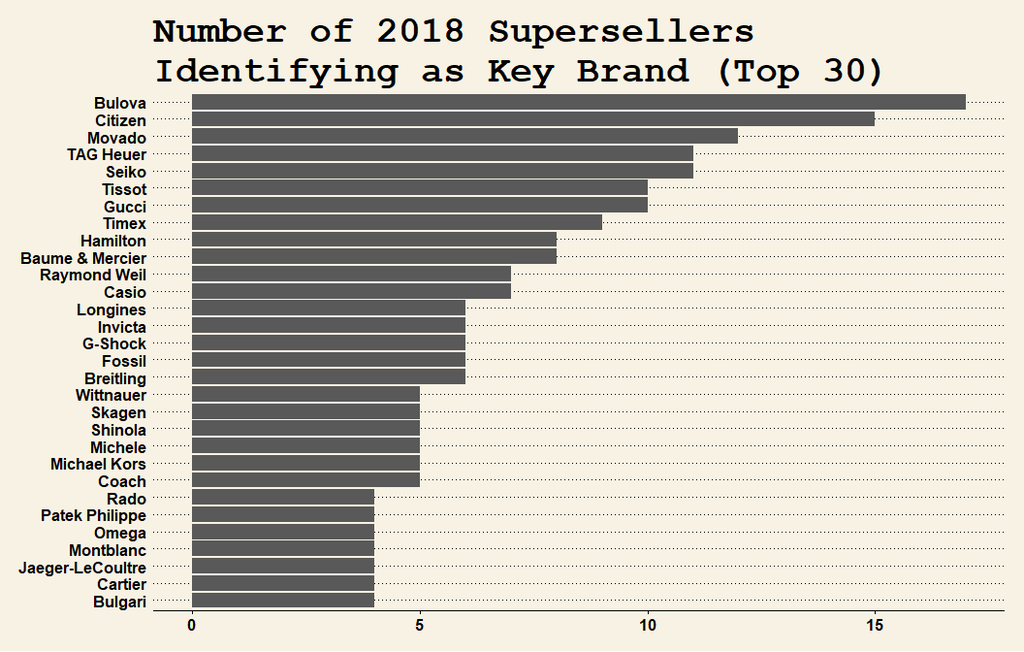

#### 2018 Top 50 Specialty Retailers:

The same information from Specialty Jewlery store chains may be more interesting as the size of individual stores more closely reflects the market segment for Henry Wilson Jewelers. These retailers include:

| Retailer | Number of Watch Brands Carried |
| --- | --- |
| DIAMONDS INTERNATIONAL | 51 |
| SIGNET JEWELERS LIMITED | 27 |
| LITTLE SWITZERLAND* ST. THOMAS | 23 |
| SCHIFFMAN’S JEWELERS | 22 |
| REEDS JEWELERS INC. | 21 |
| SWATCH GROUP | 17 |
| THE JEWELERS INC. | 16 |
| ANN-LOUISE JEWELLERS LTD. | 16 |
| FINK’S JEWELERS INC. | 14 |
| LEE MICHAELS FINE JEWELRY* | 14 |
| TOURNEAU LLC* | 13 |
| BEN BRIDGE CORPORATION P.O. BOX | 13 |
| BIRKS GROUP INC.* | 11 |
| COMPAGNIE FINANCIÈRE RICHEMONT SA NEW YORK NY | 11 |
| MOVADO RETAIL GROUP INC. | 11 |
| ROGERS ENTERPRISES INC. | 9 |
| HELZBERG DIAMONDS | 8 |
| REEDS/JENSS | 8 |
| LVMH MOËT HENNESSY LOUIS VUITTON S.E. | 7 |
| RIDDLE’S GROUP INC. | 7 |
| CHARM JEWELRY LTD.* | 6 |
| SHERWOOD MANAGEMENT CO. | 6 |
| MICHAELS JEWELERS P.O. BOX | 5 |
| HANNOUSH JEWELERS EASTFIELD MALL | 4 |
| DON ROBERTO JEWELERS INC. SAN CLEMENTE CA | 3 |
| PARIS JEWELLERS | 3 |
| FRED MEYER JEWELERS | 3 |
| MORGAN MANAGEMENT P.O. BOX | 3 |
| SAMUELS JEWELERS INC.* | 3 |
| DUNKIN’S DIAMONDS | 2 |
| INTERNATIONAL DIAMOND CENTER CLEARWATER FL | 2 |
| JENSEN JEWELERS OF IDAHO LLC TWIN FALLS ID | 2 |
| S. SASLOW INCORPORATED PO BOX | 2 |
| HARRY RITCHIE JEWELERS INC. | 2 |
| TIFFANY & CO. | 2 |
| DEVONS JEWELERS ARDEN FAIR | 1 |
| DIAMONDS DIRECT INC. | 1 |
| GOLDENWEST DIAMOND CORP. | 1 |
| GREEN MANAGEMENT P.O. BOX | 1 |
| GRUPO REINHOLD | 1 |
| MICHAEL HILL INTERNATIONAL LTD.* MISSISSAUGA ON L | 1 |
| NA HOKU INC. | 1 |
| PERELMAN’S FAMILY JEWELRY INC. NEW CASTLE PA | 1 |
| ROBBINS BROTHERS JEWELRY INC. P.O. BOX | 1 |
| SHANE CO. | 1 |
| DAVID YURMAN ENTERPRISES LLC | 1 |
| HARRIS ORIGINALS | 1 |
| JAMES AVERY CRAFTSMAN INC. | 1 |
| MAUI DIVERS | 1 |
| PANDORA A/S P.O. BOX | 1 |
| SWAROVSKI AG | 1 |
| WEDDING DAY DIAMONDS | 1 |

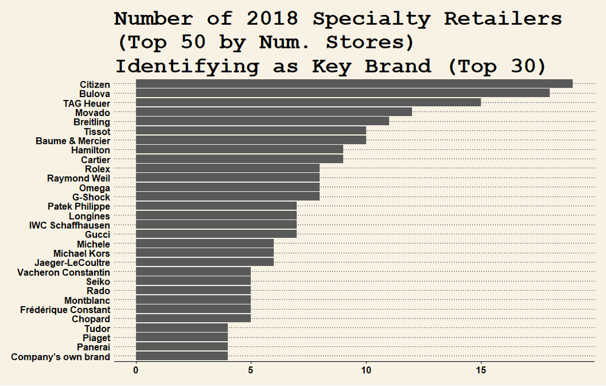

#### Analysis of Data Over Time

In addition to the 2018 magazine, data is also available beginning in 2016 allowing to observe how the brands specific retailers have carried over time have changed. For the purposes of this historical analysis, the focus will be solely on Specialty Jewelers and not the Supersellers.

As an example, we can identify which watch brands have been picked up by the largest number of retailers since 2016. The below brands were picked up by more than 2 specialty retailers since 2016.

| Brand | 2016 | 2018 | Growth |
| --- | --- | --- | --- |
| Bulova | 12 | 18 | 6 |
| G-Shock | 2 | 8 | 6 |
| Omega | 3 | 8 | 5 |
| Michele | 2 | 6 | 4 |
| Chopard | 2 | 5 | 3 |
| Frédérique Constant | 2 | 5 | 3 |
| Longines | 4 | 7 | 3 |
| Movado | 9 | 12 | 3 |
| Patek Philippe | 4 | 7 | 3 |
| Rado | 2 | 5 | 3 |

The below plot demonstrates the top 10 of the most carried brands by Specialty Retailers and their 3 year trend.

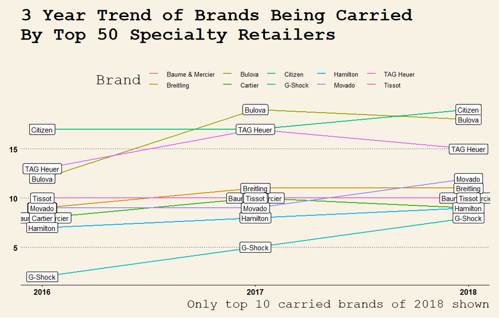